# U3. WINDOWS SERVER. ADMINISTRACIÓ I CONFIGURACIÓ (II)

### Protecció contra eliminació i canvi accidental

Quan intentem moure o eliminar una UO tenim un missatge avisant que el canvi pot fer que deixen d’alicar-se directives o afectar als usuaris que la controlen (per exemple).

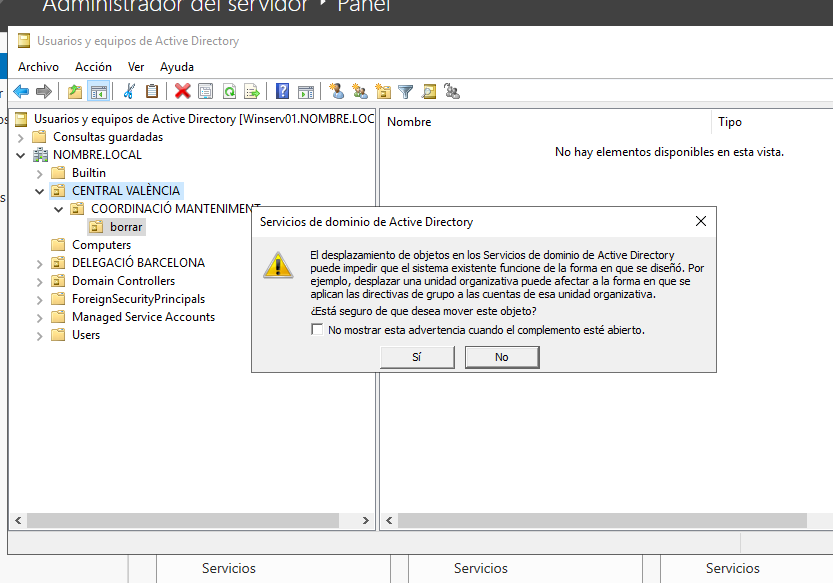

Si acceptem veiem que és habitual que no ens deixe.

[figure not shown]

Per defecte es creen protegides per evitar eliminacions o canvis d’ubicació accidentals. Ho hem de desprotegir prèviament.

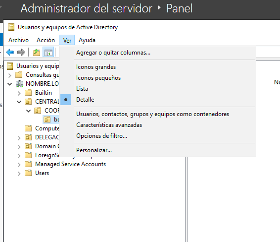

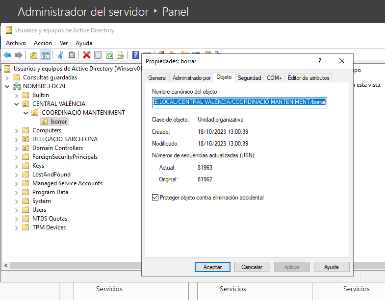

### Delegació

És interessant que assignem el control dels objectes i recursos de la delegació territorial/secció de l’empresa/projecte a un usuari.

> Note El més habitual serà que l’usuari siga Administrador i puga iniciar sessió de forma remota. Consulteu la fitxa de Escriptori Remot

# 4 Servei DNS

L’objecte del mòdul no és l’estudi dels serveis sinó dels Sistemes Operatius. En aquest cas la integració del servei DNS amb el Windows Server.

- Un enfoc teòric en aquest apartat
- Vorem, més avant, alguns cmdLets per instal·lar/desinstal·lar, consultar i fer algun canvi.

## 4.1 La integració del DNS al servei AD DS

El servei de servidor DNS està integrat en el disseny i implementació dels serveis de domini d’Active Directory (AD DS), proporcionant una eina empresarial per organitzar, gestionar i localitzar recursos en una xarxa.

Quan implementeu servidors DNS amb AD DS, tingueu en compte que:

- El DNS és necessari per localitzar els controladors de domini.
- El servei d’inici de sessió a la xarxa utilitza el servidor DNS per registrar els controladors de domini al vostre espai de noms DNS.
- Els servidors DNS amb Windows Server poden utilitzar AD DS per emmagatzemar i replicar les zones DNS.
- La integració de zones DNS amb AD DS permet funcions com la rèplica d’AD DS, actualitzacions dinàmiques segures, i l’envelliment i eliminació de registres.

**Com s’integra DNS amb AD DS**

Quan instal·leu AD DS en un servidor i el promocioneu a controlador de domini, se us demana que especifiqueu un nom de domini DNS per al domini AD DS. A més, se us ofereix l’opció d’instal·lar el servidor DNS, ja que és necessari per localitzar controladors de domini dins del domini AD DS.

## 4.2 Beneficis de la integració d’AD DS

Per a xarxes que utilitzen DNS per a AD DS, es recomana utilitzar zones primàries integrades al directori, ja que aporten diversos beneficis:

- **Replicació multimaster**: Amb AD DS, qualsevol servidor DNS pot acceptar actualitzacions dinàmiques i replicar-les entre tots els servidors DNS.
- **Seguretat millorada**: Mitjançant ACLs, es poden restringir les actualitzacions dinàmiques per a equips o grups específics, cosa que no és possible amb zones primàries estàndard.
- **Automatització i sincronització**: Quan es crea un nou controlador de domini, les zones es repliquen automàticament.
- **Millor rendiment**: La sincronització de les zones integrades al directori és més eficient que les actualitzacions estàndard, evitant la transferència de tota la zona.

Si integreu les zones DNS amb AD DS, també simplifiqueu la gestió de la rèplica de bases de dades, evitant la necessitat de mantenir topologies de rèplica separades per a DNS i AD DS. Aquesta integració permet visualitzar la gestió com una única entitat administrativa.

Finalment, només les zones primàries es poden emmagatzemar al directori. Les zones secundàries han d’emmagatzemar-se en fitxers de text estàndard, però amb el model de replicació multimaster d’AD DS, no són necessàries si totes les zones estan en AD DS.